# Fetal effects on miscarriage - Preliminary data from MoBa

Pol Sole Navais

2023-02-04

# Rationale

Human reproduction is highly inefficient; pregnancy loss is estimated to affect almost 70% of all conceptions and is the most common pregnancy outcome. Aneuploidies are one of the major causes of miscarriage, particularly early in pregnancy. Aneuploidies likely disrupt multiple pathways, making it difficult to improve our knowledge on the biological mechanisms behind miscarriage. It is increasingly evident that, cumulatively, small genetic effects scattered across the genome have a profound impact on human traits, even on those previously considered as monogenic (e.g. eye color). Only one GWAS of miscarriage has been performed to date, and used the maternal genome. Performing a fetal GWAS of miscarriage may clarify to what extent the fetal genome contributes to miscarriage beyond aneuploidies, provide meaningful biology behind miscarriage and, potentially, improve reproductive health.

# Phenotype

## Distribution that best fits the data

Normal distribution:

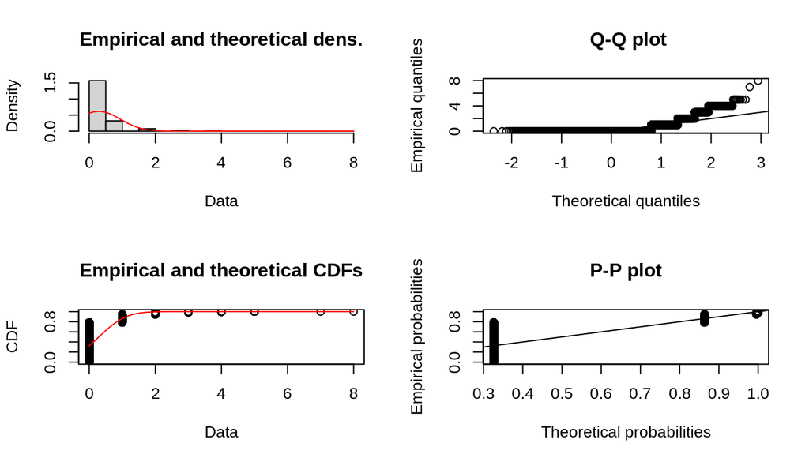

Poisson distribution:

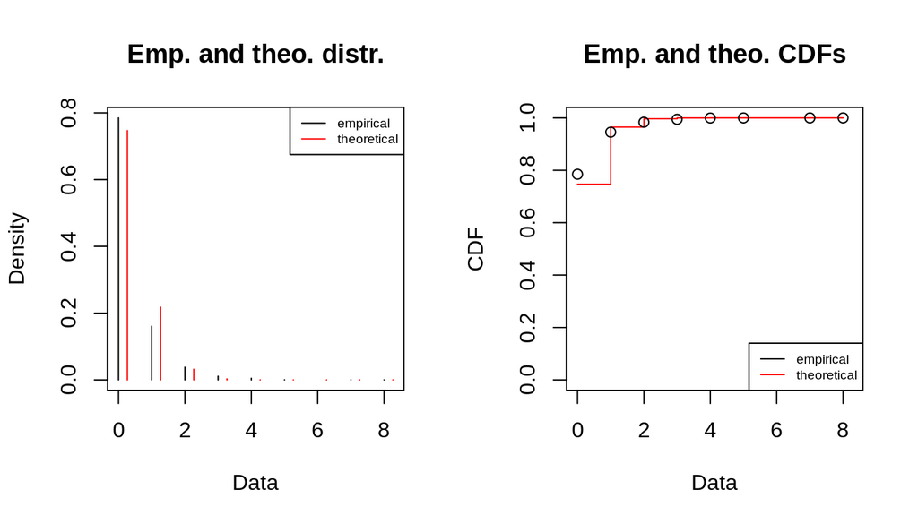

One assumption of poisson distributions is that mean and variance should be equal:

[output not shown]

[output not shown]

Negative binomial:

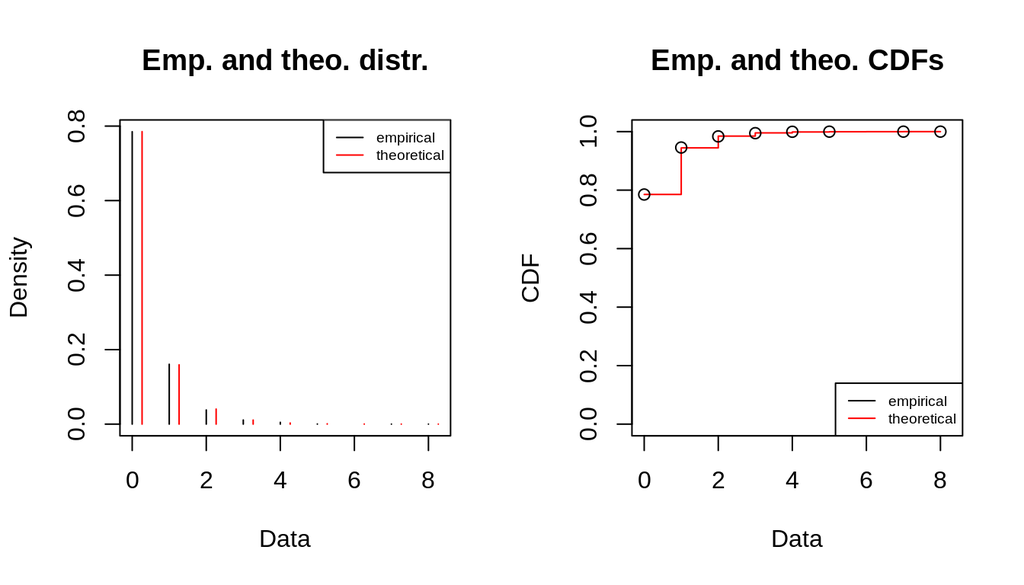

# GWAS

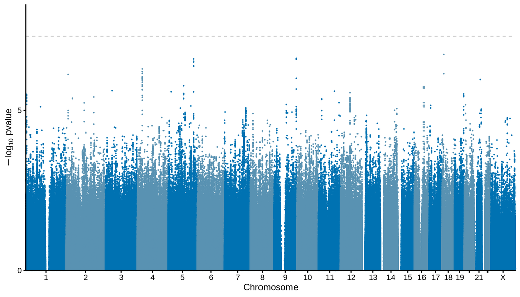

# QQ-plot

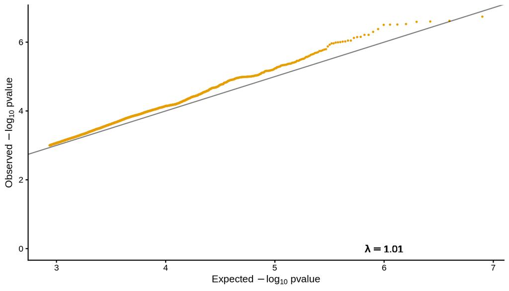

# Hardy-Weinberg equilibrium

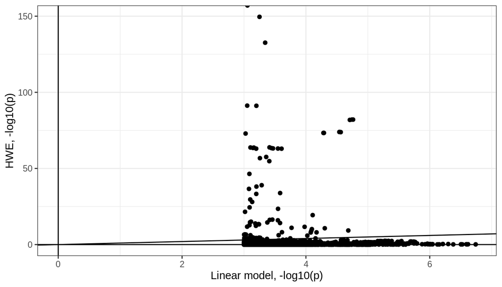

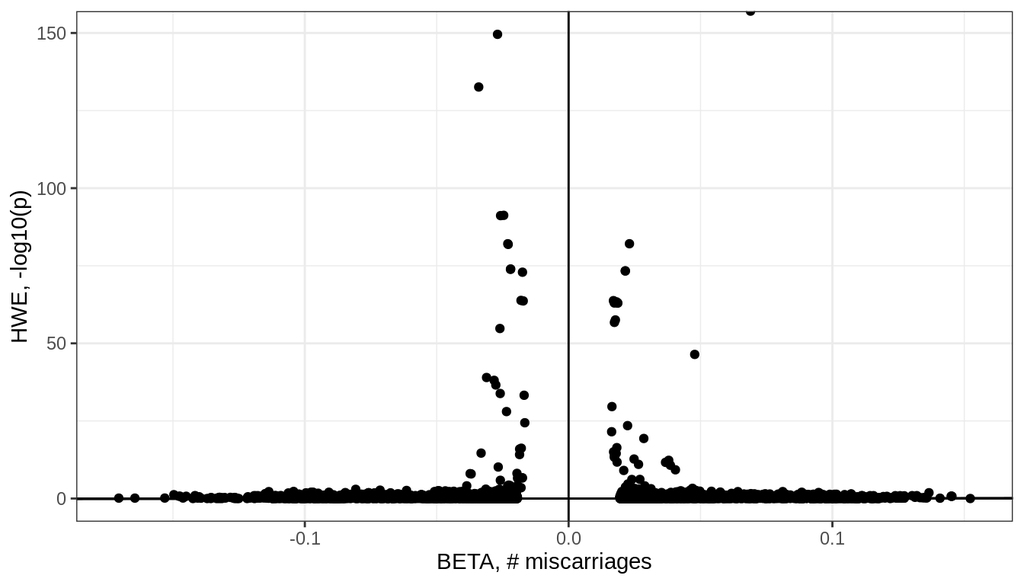

# EAF

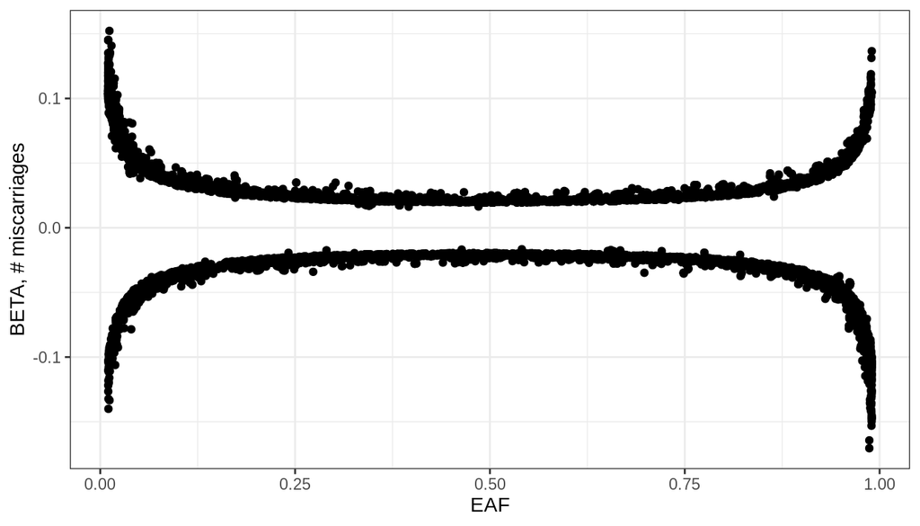

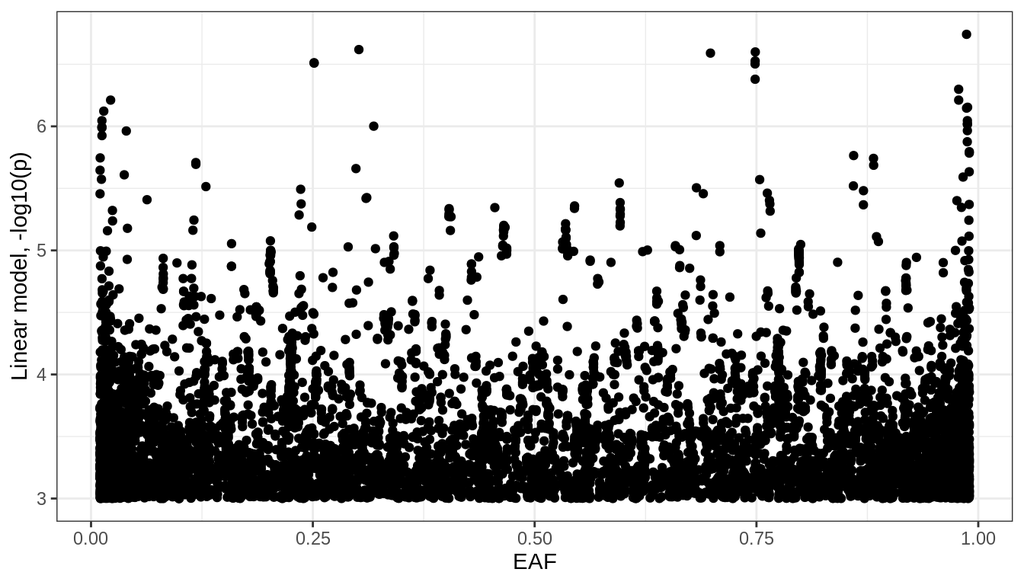